# 콜미 콜미

2019년 5월 2일

## 조구성

- 지현주: 문제 정의 & 데이터 소개
- 강형구: 언어 및 고구 & 분석 산물
- 윤예슬: 해결방향 & 일정 & 기대효과

## 장애인 콜택시란

- 2002년부터 서울시에서 제공하는 복지 프로그램
1. 이용대상: 장애등급
   - 출퇴근 / 통학 / 진료 목적의 이동
   - 장애등급 1급이나 2급 판정을 받은 자
   - 장애등급 3급을 판정받은 임산부
2. 이용요금

| **5km이내** | **5-10km** | **10km초과** |
| --- | --- | --- |
| **1,500원** | **2,900원** | **70원/km 추가** |

## 장애인 콜택시란(cont.)

1. 이용 지역: 서울시, 인접 수도권(부천, 김포, 양주, 고양, 의정부, 남양주, 구리, 하남, 과천, 안양, 광명, 성남, 인천국제공항)
2. 신청 방법: 전화/문자/인터넷/모바일

[서울시설공단 장애인 콜택시](https://www.sisul.or.kr/open_content/calltaxi/introduce/intro.jsp)

## 문제 정의

### **장애인의 이동권**

- 장애인들이 이용할 수 있는 교통수단의 부족은 이들의 이동권을 직접적으로 침해함
- 특히나 장애 1급/2급을 판정받은 중증장애인들은 휠체어 사용률이 높아, 휠체어가 탑승 가능한 교통수단이 필수적
- 2018 장애인 보고서(한국장애인고용공단 고용개발원, 2018)에 따르면, 전체 장애인들이 이용하는 교통수단 중 자가용 33.5%이 압도적인 1위를 차지-> 사회적 체계가 미흡하고, 장애인 돌봄이 가족의 역할로 미뤄지고 있음

## 문제 정의(cont.)

- 2018 장애인 보고서
1. 장애인 콜택시 이용 희망: 37.1%
2. 장애인 콜택시 이용 비율: 5.3%

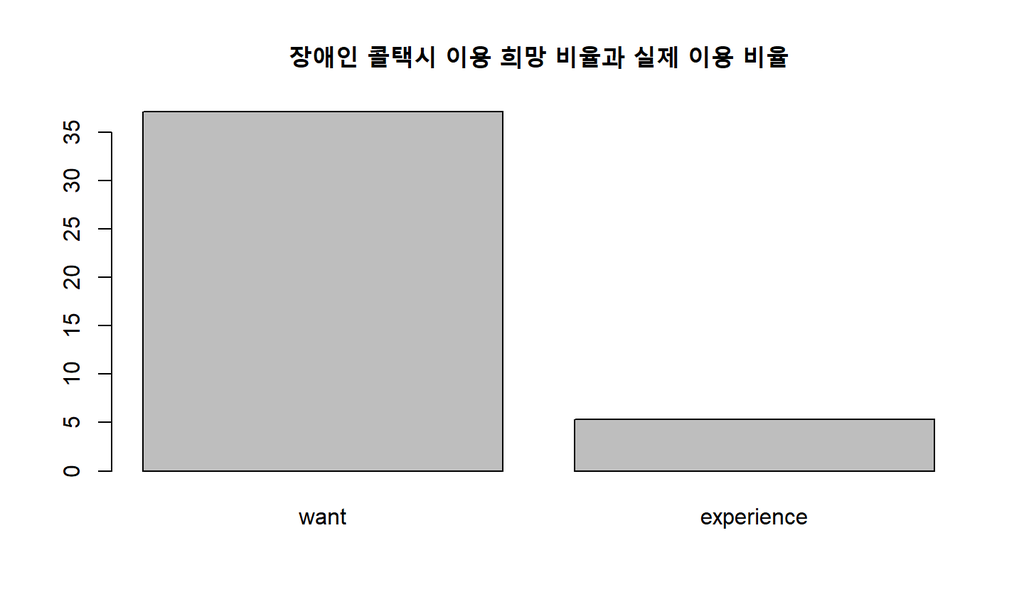

## 문제 정의(cont.)

*장애인 콜택시 사업 확장의 필요성*

[figure not shown]

이미지1

## 장애인 복지법

제23조(편의시설) ①국가와 지방자치단체는 **장애인이 공공시설과 교통수단 등을 안전하고 편리하게 이용할 수 있도록** 편의시설의 설치와 운영에 필요한 정책을 강구하여야 한다.

## 문제 정의(cont.)

- 장애인 콜택시를 얼마나 확충해야 할까?
- 희망 건수와 탑승 건수를 비교
- 어느 요일 & 어느 목적지에서 이용이 많은지 파악
- 현재 차량 운행 수준과 탑승 건수를 비교하여, 앞으로 몇 대가 확충되어야 할지 제시

## 데이터 소개

- 공공데이터포털: [장애인콜택시 이용현황](https://www.data.go.kr/dataset/15002857/openapi.do)
1. 장애인콜택시 탑승 통계
   - 변수: 기준일(운행일자), 차량운영, 희망건, 탑승건, 평균대기시간, 평균요금, 평균 승차거리
   - 제공받은 데이터: 2018.07.14-2018.08.14
2. 목적지 Best 100
   - 변수: 운행일자, 고객이용 목적지 시도, 고객이용, 목적지 시군구, 고객이용 목적지 동, 해당 이용의 목적지 건수
   - 제공받은 데이터: 2018.07.18. top 100
- 추가 데이터 (가능하면 1년치) 요청해둔 상황!

## 데이터 살펴보기: 장애인콜택시 탑승 통계

```
##    taxi_date taxi_count taxi_want taxi_use taxi_wait_time taxi_ave_fee
## 1   20180714        266      2246     1684           66.1         2546
## 2   20180715        220      1984     1731           47.1         2450
## 3   20180716        496      5060     4043           67.7         2234
## 4   20180717        524      5605     4187           62.5         2239
## 5   20180718        499      5062     4099           60.7         2259
## 6   20180719        541      5167     4174           58.0         2239
## 7   20180720        522      5202     4085           62.7         2241
## 8   20180721        277      2277     1713           59.5         2460
## 9   20180722        204      1934     1614           53.5         2471
## 10  20180723        515      5061     4027           67.8         2244
## 11  20180724        538      5028     3889           68.5         2227
## 12  20180725        471      5007     3901           68.6         2264
## 13  20180726        507      4858     3761           60.4         2261
## 14  20180727        510      5065     3846           63.2         2246
```

[output cut: 51 more lines]

## 데이터 살펴보기: 장애인콜택시 탑승 통계(cont.)

```
##    taxi_date          taxi_count      taxi_want       taxi_use
##  Min.   :20180714   Min.   :202.0   Min.   :1885   Min.   :1614
##  1st Qu.:20180722   1st Qu.:286.0   1st Qu.:2269   1st Qu.:1766
##  Median :20180730   Median :504.5   Median :4985   Median :3859
##  Mean   :20180760   Mean   :428.9   Mean   :4146   Mean   :3269
##  3rd Qu.:20180806   3rd Qu.:517.5   3rd Qu.:5072   3rd Qu.:4088
##  Max.   :20180814   Max.   :557.0   Max.   :5605   Max.   :4208
##  taxi_wait_time   taxi_ave_fee  taxi_ave_distance
##  Min.   :35.80   Min.   :2203   Min.   : 8288
##  1st Qu.:48.15   1st Qu.:2239   1st Qu.: 8557
##  Median :57.60   Median :2254   Median : 8718
##  Mean   :55.50   Mean   :2308   Mean   : 9195
##  3rd Qu.:62.83   3rd Qu.:2412   3rd Qu.:10111
##  Max.   :68.60   Max.   :2546   Max.   :11239
```

## 데이터 살펴보기: 목적지 Best 100

```
##     place_date            dong place_count
## 1     20180718         하계1동          91
## 2     20180718       상계6.7동          86
## 3     20180718          역촌동          79
## 4     20180718          신촌동          77
## 5     20180718       성산제2동          62
## 6     20180718          인수동          56
## 7     20180718          이화동          45
## 8     20180718         신내1동          45
## 9     20180718          상암동          43
## 10    20180718       방화제1동          42
## 11    20180718        영등포동          41
## 12    20180718          연희동          40
## 13    20180718       구의제2동          36
## 14    20180718         풍납2동          36
```

[output cut: 86 more lines]

## 데이터 살펴보기: 목적지 Best 100

```
## 'data.frame':    100 obs. of  3 variables:
##  $ place_date : num  20180718 20180718 20180718 20180718 20180718 ...
##  $ dong       : Factor w/ 100 levels "가양제2동","강일동",..: 95 44 67 61 51 80 79 55 46 32 ...
##  $ place_count: num  91 86 79 77 62 56 45 45 43 42 ...
```

```
##    place_date              dong     place_count
##  Min.   :20180718   가양제2동: 1   Min.   :11.00
##  1st Qu.:20180718   강일동   : 1   1st Qu.:13.00
##  Median :20180718   개봉제1동: 1   Median :17.00
##  Mean   :20180718   거여2동  : 1   Mean   :22.94
##  3rd Qu.:20180718   고덕제1동: 1   3rd Qu.:26.50
##  Max.   :20180718   공덕동   : 1   Max.   :91.00
##                     (Other)  :94
```